# Titanic Angela & Francisco

We start loading all the libraries that we will need during the homework.

```r
library(ggplot2)
library(RColorBrewer)
```

We now load the data and have a quick look at it. Noticing data-types with the str command.

```r
load("/Users/curro/Desktop/Titanic1/titanic_train.Rdata")
head(titanic.train)
```

|  | Survived | Pclass | Sex | Age | SibSp | Parch | Ticket | Fare | Cabin | Embarked |
| --- | --- | --- | --- | --- | --- | --- | --- | --- | --- | --- |
| 2 | 1 | 1 | female | 38 | 1 | 0 | PC 17599 | 71.2833 | C85 | C |
| 5 | 0 | 3 | male | 35 | 0 | 0 | 373450 | 8.0500 |  | S |
| 7 | 0 | 1 | male | 54 | 0 | 0 | 17463 | 51.8625 | E46 | S |
| 10 | 1 | 2 | female | 14 | 1 | 0 | 237736 | 30.0708 |  | C |
| 11 | 1 | 3 | female | 4 | 1 | 1 | PP 9549 | 16.7000 | G6 | S |
| 14 | 0 | 3 | male | 39 | 1 | 5 | 347082 | 31.2750 |  | S |

```r
str(titanic.train)
```

```
'data.frame':   668 obs. of  10 variables:
 $ Survived: Factor w/ 2 levels "0","1": 2 1 1 2 2 1 1 2 1 2 ...
 $ Pclass  : Factor w/ 3 levels "1","2","3": 1 3 1 2 3 3 3 2 3 2 ...
 $ Sex     : Factor w/ 2 levels "female","male": 1 2 2 1 1 2 1 1 2 2 ...
 $ Age     : num  38 35 54 14 4 39 14 55 2 28 ...
 $ SibSp   : int  1 0 0 1 1 1 0 0 4 0 ...
 $ Parch   : int  0 0 0 0 1 5 0 0 1 0 ...
 $ Ticket  : Factor w/ 681 levels "110152","110413",..: 597 473 86 133 617 334 414 154 481 152 ...
 $ Fare    : num  71.28 8.05 51.86 30.07 16.7 ...
 $ Cabin   : Factor w/ 148 levels "","A10","A14",..: 83 1 131 1 147 1 1 1 1 1 ...
 $ Embarked: Factor w/ 4 levels "","C","Q","S": 2 4 4 2 4 4 4 4 3 4 ...
```

## Analysis for each variable

We start extracting the main characteristics from each variable.

#### Survival Chances -> Survived (0 = No; 1 = Yes)

```r
summary(titanic.train$Survived)
```

```
  0   1
412 256
```

```r
round(prop.table(table(titanic.train$Survived)),3)  #me make the prop table and summaries like in the lab sessions
```

```
    0     1
0.617 0.383
```

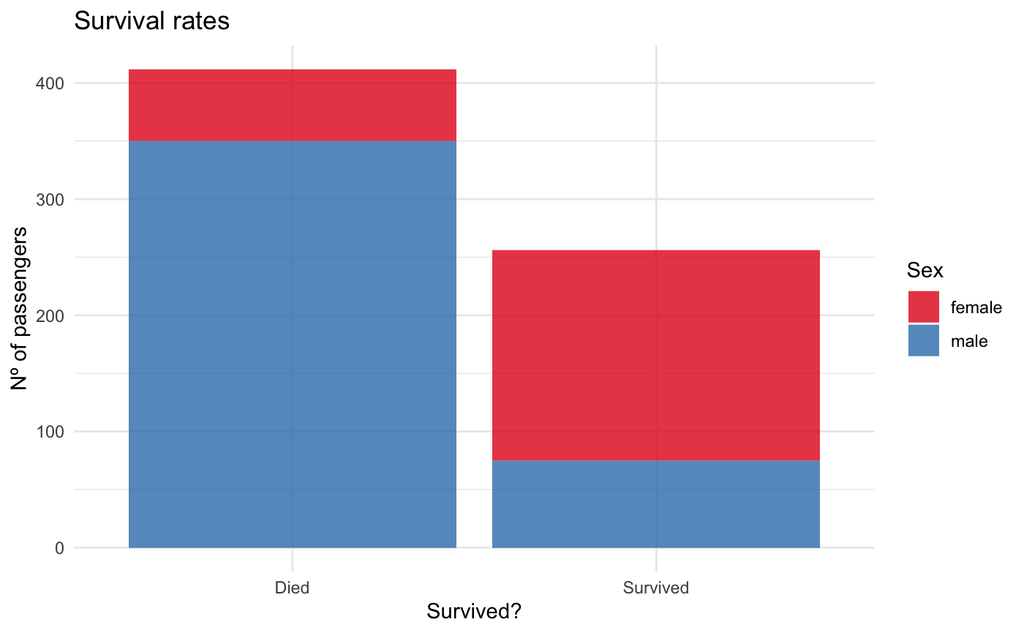

```r
ggplot(titanic.train)+
  geom_bar(aes(x = Survived, fill = Sex), alpha=0.8)+  labs(title="Survival rates", #we plot some of the results and make                                                                                                it look understandable
       x="Survived?",
       y="Nº of passengers") +
  scale_fill_brewer(palette = "Set1")+
  theme_minimal()+
  scale_x_discrete(labels=c("Died", "Survived"))
```

We can ensure that the 61.7% of the passengers couldn’t finish the trip while the other 38.3% could. After plotting the survival rates, we use the command fill to see how it’s influenced by gender noticing that the passengers who survived the most were women.

#### Passenger Class -> Pclass (1 st class, 2 nd class, 3 rd class)

```r
table(titanic.train$Pclass)
```

```
  1   2   3
167 138 363
```

```r
round(prop.table(table(titanic.train$Pclass)),3)            #we repeat the same methodology, no explanation needed
```

```
    1     2     3
0.250 0.207 0.543
```

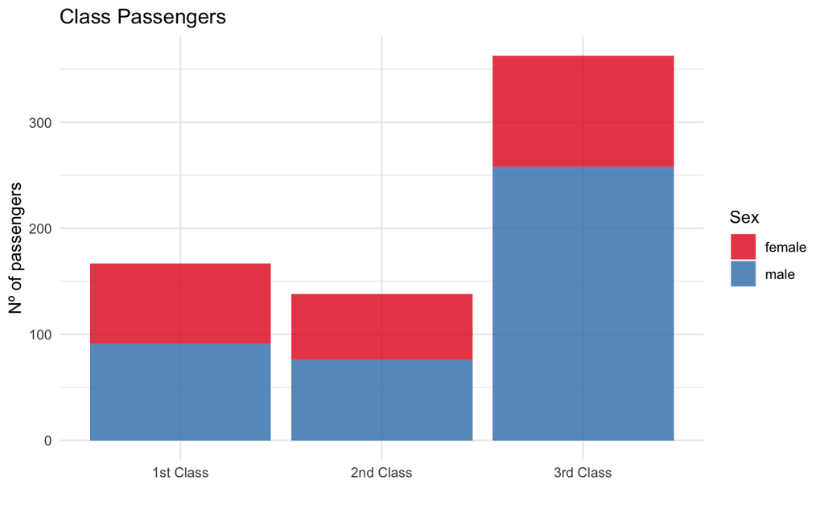

```r
ggplot(titanic.train)+
  geom_bar(aes(x = Pclass, fill=Sex), alpha=0.8)+
  labs(title="Class Passengers",
       x="",
       y="Nº of passengers") +
  scale_fill_brewer(palette = "Set1")+
  theme_minimal()+
  scale_x_discrete(labels=c("1st Class", "2nd Class","3rd Class"))
```

We conclude that there were more passengers in 3rd class and highlight that in this class, there are a lot of men. This may help us to formulate some questions in a near future.

#### Age -> Passenger’s age

```r
summary(titanic.train$Age)
```

```
   Min. 1st Qu.  Median    Mean 3rd Qu.    Max.
   0.42   22.00   28.00   29.15   35.00   74.00
```

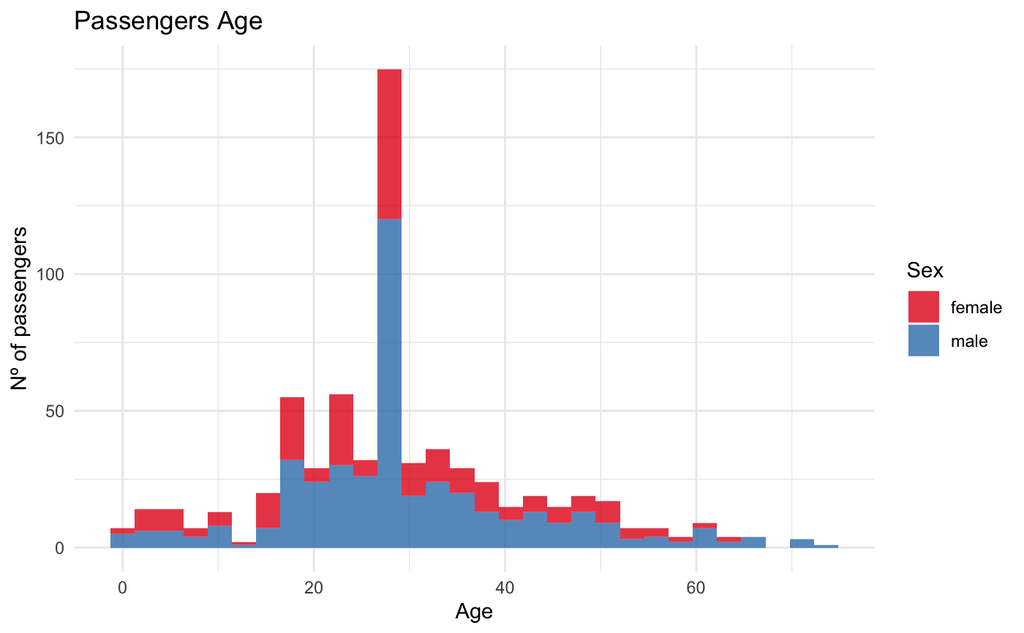

```r
ggplot(titanic.train)+
  geom_histogram(aes(x = Age, fill=Sex), alpha=0.8)+
  labs(title="Passengers Age",
       x="Age",
       y="Nº of passengers") +
  scale_fill_brewer(palette = "Set1")+
  theme_minimal()
```

We observe how the age is distributed among the passengers and sex, highlighting that there were more men than women. The mean age was around 29 years old and the older passenger was 74 years old. To appreciate a little bit better this variable we create a boxplot.

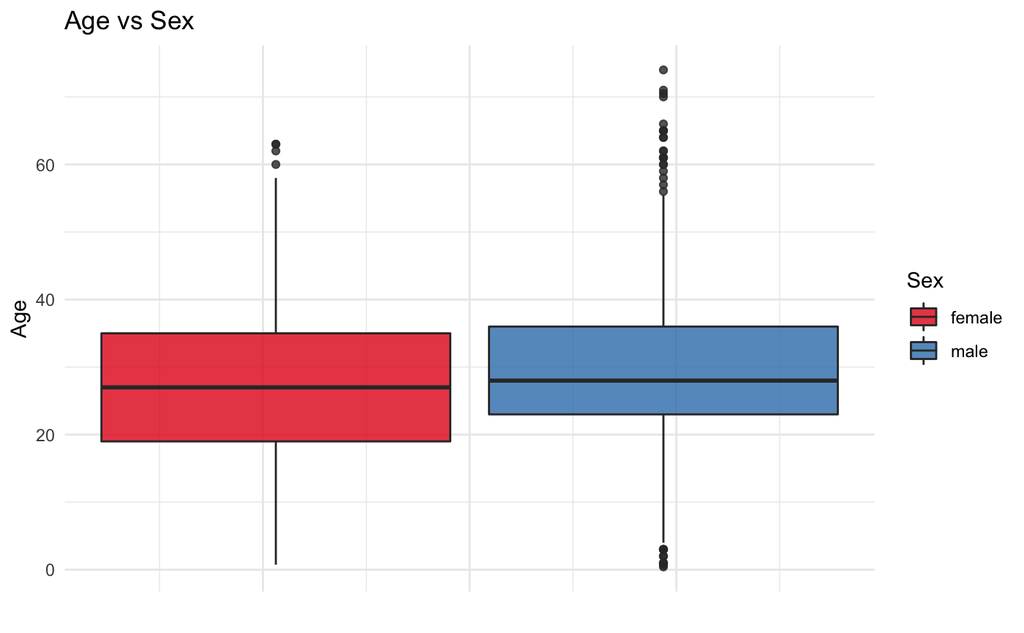

```r
ggplot(titanic.train)+
  geom_boxplot(aes(x = Age, fill=Sex), alpha=0.8)+
  labs(title="Age vs Sex",
       x="Age",
       y="") +
  scale_fill_brewer(palette = "Set1")+
  theme_minimal()+
  coord_flip()+
  theme(axis.text.x = element_blank())
```

We can see better the results of the summary command in this plot. Noticing some outliers, which may be interesting to navigate through while answering some questions, and that men and women had similar ages.

#### Fares -> Prices in pounds

```r
summary(titanic.train$Fare)
```

```
   Min. 1st Qu.  Median    Mean 3rd Qu.    Max.
  0.000   7.925  15.246  34.066  34.109 512.329
```

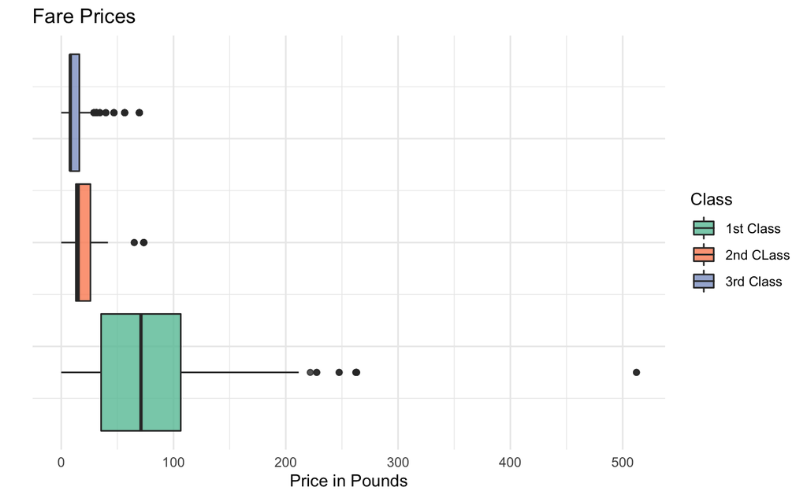

```r
ggplot(titanic.train)+
  geom_boxplot(aes(x = Fare, fill=Pclass), alpha=0.8)+
  labs(title="Fare Prices",
       fill="Class",
       x="Price in Pounds",
       y="") +
  scale_fill_brewer(palette = "Set2", labels = c("1st Class", "2nd CLass", "3rd Class"))+
  theme_minimal()+
  theme(axis.text.y = element_blank())
```

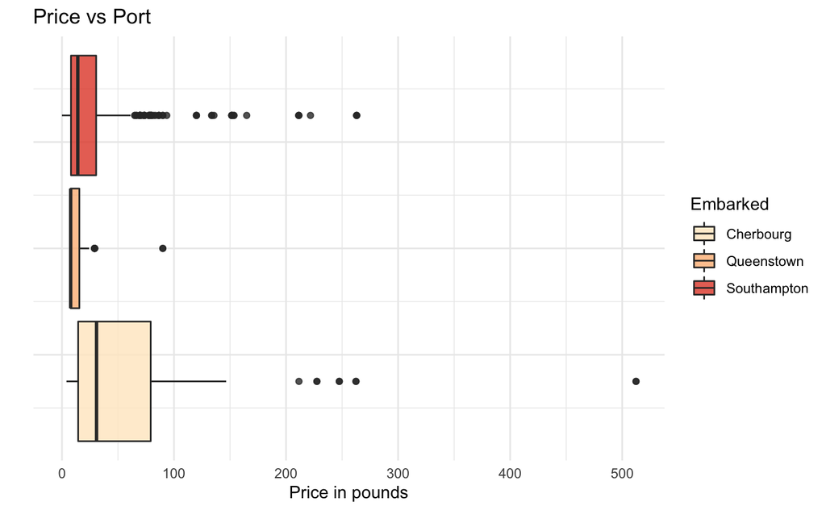

```r
ggplot(titanic.train)+
  geom_boxplot(aes(x = Fare, fill=Embarked), alpha=0.8)+
  labs(title="Price vs Port",
       x="Price in pounds",
       y="") +
  scale_fill_brewer(palette = "OrRd",labels = c("Cherbourg", "Queenstown", "Southampton"))+
  theme_minimal()+
  theme(axis.text.y = element_blank())
```

There is a mean value for a fare of 34 pounds, which is conditioned by some of the outliers we just saw on the boxplot. It will be very curious to see if the people who paid more than 100 pounds for a ticket survived or not. In addition we figure out that not many people traveled in second class.

#### Embarking Port -> Cherbourg, Queenstown and Southampton

```r
table(titanic.train$Embarked)
```

```
      C   Q   S
  0 132  57 479
```

```r
round(prop.table(table(titanic.train$Embarked)),3)
```

```
          C     Q     S
0.000 0.198 0.085 0.717
```

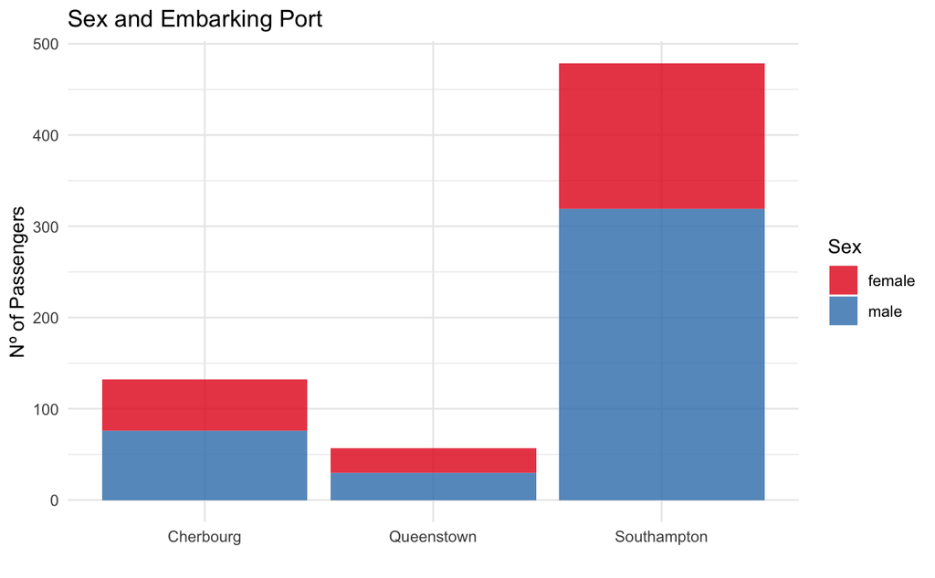

```r
ggplot(titanic.train)+
  geom_bar(aes(x = Embarked, fill=Sex), alpha=0.8)+
  labs(title="Sex and Embarking Port",
       x="",
       y="Nº of Passengers") +
  scale_fill_brewer(palette = "Set1")+
  theme_minimal()+
  scale_x_discrete(labels=c("Cherbourg", "Queenstown","Southampton"))
```

#### Sibligs or Spouses -> SibSp

```r
summary(titanic.train$SibSp)
```

```
   Min. 1st Qu.  Median    Mean 3rd Qu.    Max.
 0.0000  0.0000  0.0000  0.5748  1.0000  8.0000
```

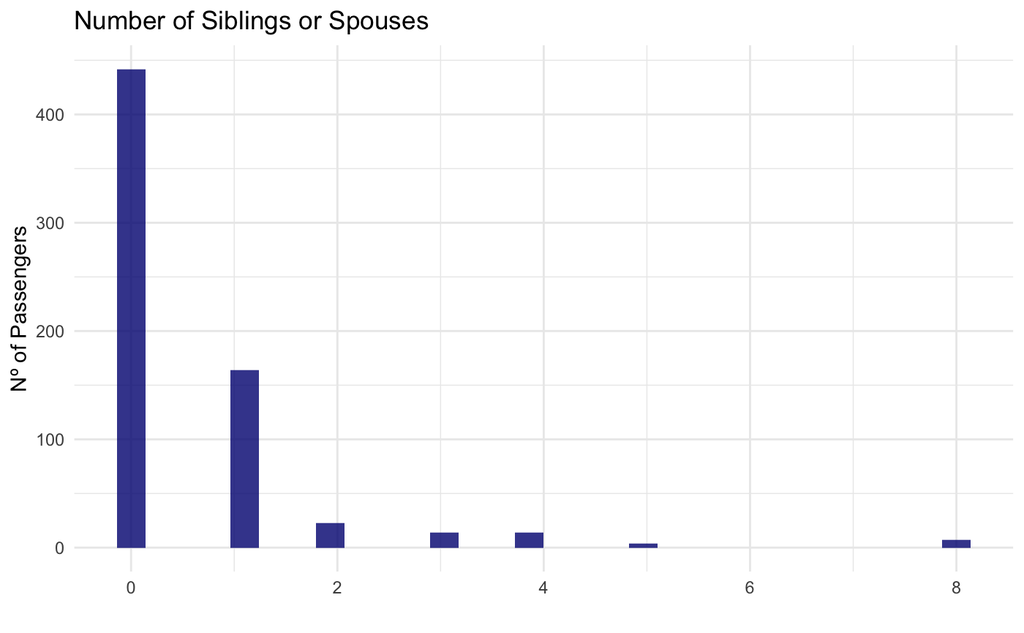

```r
ggplot(titanic.train)+
  geom_histogram(aes(x = SibSp), fill = "Navyblue", alpha=0.8)+
  labs(title="Number of Siblings or Spouses",
       x="",
       y="Nº of Passengers") +
  theme_minimal()
```

Most passengers went with nor siblings or spouses.

#### Parents or Children -> Parch

```r
summary(titanic.train$Parch)
```

```
   Min. 1st Qu.  Median    Mean 3rd Qu.    Max.
 0.0000  0.0000  0.0000  0.4042  0.0000  6.0000
```

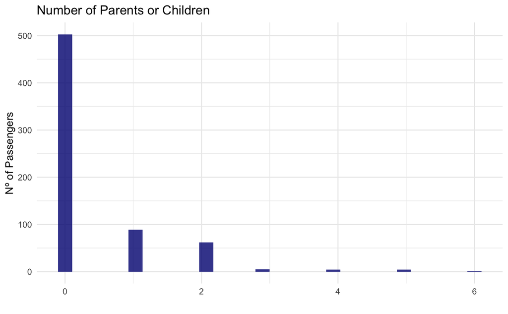

```r
ggplot(titanic.train)+
  geom_histogram(aes(x = Parch), fill = "Navyblue", alpha=0.8)+
  labs(title="Number of Parents or Children",
       x="",
       y="Nº of Passengers") +
  theme_minimal()
```

We appreciate that a lot of people went alone to the trip.

## Our questions

While analyzing all the variables we came up with the following questions, we will answer them one by one.

### 1.- Passengers survived depending on which class they had?

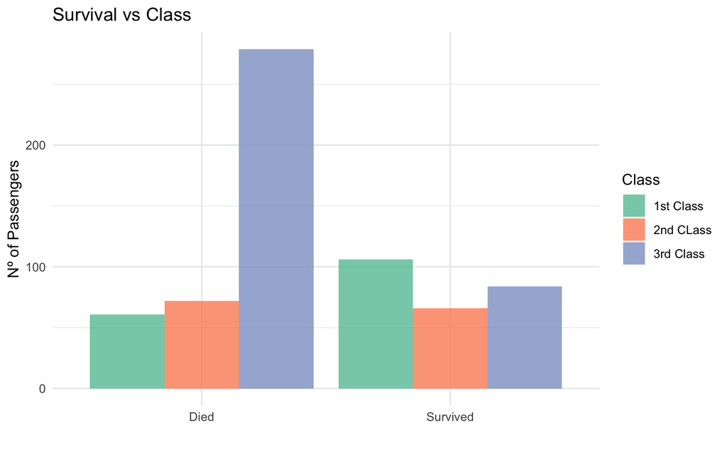

```r
ggplot(titanic.train)+
  geom_bar(aes( x = Survived, fill = Pclass),position=position_dodge(), alpha=0.8)+
  labs(title="Survival vs Class",
       x="",
       fill="Class",
       y="Nº of Passengers") +
  scale_fill_brewer(palette = "Set2", labels = c("1st Class", "2nd CLass", "3rd Class"))+
  theme_minimal()+
  scale_x_discrete(labels=c("Died", "Survived"))
```

If we have a look at this plot, we can see how people in 3rd class were less likely to survive after the incident. Despite the fact that the 3rd class was formed by the majority of the passengers. In addition, people traveling in first class were more likely to survive, if we compare the ratios.

### 2.- The passengers who paid more than 100 pounds for a ticket survived? What about who paid the most?

Consequently, we now focus on what we highlighted during the analysis of each variable. We want to see what happened with people who paid a lot.

```r
m <- which(titanic.train$Fare >= 100)                 #we filter the data to obtain people who paid more than 100 pounds
m<- titanic.train[m,]                                 #m is our "aux"
m
```

|  | Survived | Pclass | Sex | Age | SibSp | Parch | Ticket | Fare | Cabin | Embarked |
| --- | --- | --- | --- | --- | --- | --- | --- | --- | --- | --- |
| 32 | 1 | 1 | female | 27.00 | 1 | 0 | PC 17569 | 146.5208 | B78 | C |
| 89 | 1 | 1 | female | 23.00 | 3 | 2 | 19950 | 263.0000 | C23 C25 C27 | S |
| 119 | 0 | 1 | male | 24.00 | 0 | 1 | PC 17558 | 247.5208 | B58 B60 | C |
| 196 | 1 | 1 | female | 58.00 | 0 | 0 | PC 17569 | 146.5208 | B80 | C |
| 216 | 1 | 1 | female | 31.00 | 1 | 0 | 35273 | 113.2750 | D36 | C |
| 259 | 1 | 1 | female | 35.00 | 0 | 0 | PC 17755 | 512.3292 |  | C |
| 269 | 1 | 1 | female | 58.00 | 0 | 1 | PC 17582 | 153.4625 | C125 | S |
| 270 | 1 | 1 | female | 35.00 | 0 | 0 | PC 17760 | 135.6333 | C99 | S |
| 298 | 0 | 1 | female | 2.00 | 1 | 2 | 113781 | 151.5500 | C22 C26 | S |
| 300 | 1 | 1 | female | 50.00 | 0 | 1 | PC 17558 | 247.5208 | B58 B60 | C |

[output cut: 33 more lines]

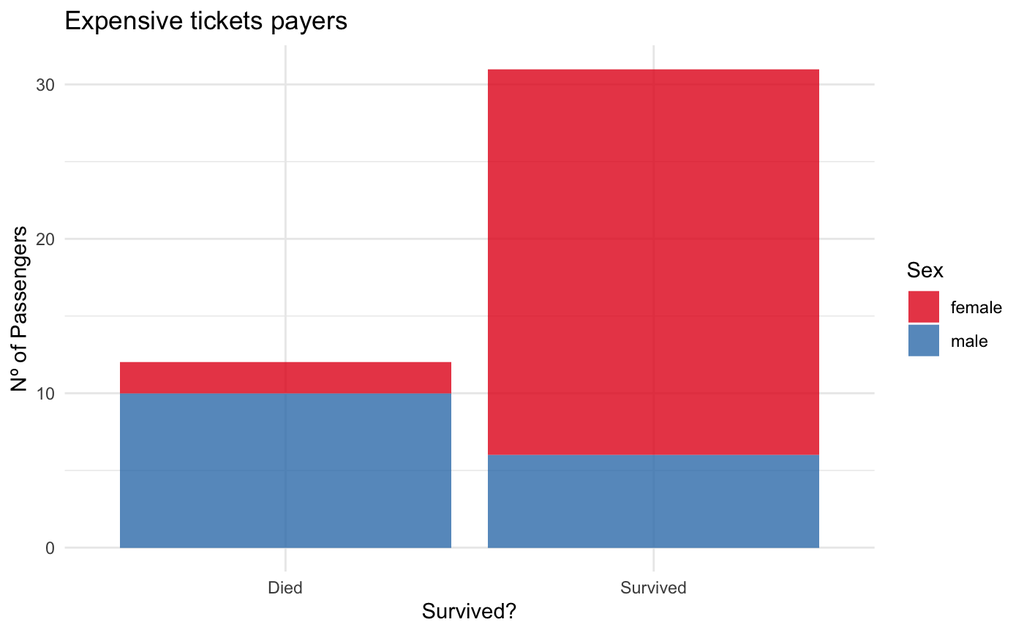

```r
ggplot(m)+
  geom_bar(aes(x = Survived, fill=Sex), alpha=0.8)+
  labs(title="Expensive tickets payers",
       x="Survived?",
       y="Nº of Passengers") +
  scale_fill_brewer(palette = "Set1")+
  theme_minimal()+
  scale_x_discrete(labels=c("Died", "Survived"))
```

Unlike we saw on the first survival rate plot, the people who paid the most had a better chance of surviving than the rest of the passengers. We believe that women had more survival chances than men not depending on the class in which they traveled. We also highlight that in first, there was a similar number of men and women.

### 3.- How many kids and old people survived comparing them with other age ranges? Does their embarking class had anything to do with it?

We will first create a new row to the dataframe, where we will segregate children (passengers younger than 18), adults (from 19 to 39, people older than 40 are not “old” but looking to the age range in the passengers we needed some more data) and elder people (more than 40 years old).

```r
young <- which(titanic.train$Age <= 18)
adult <- which(titanic.train$Age > 18 & titanic.train$Age<=39)            #we filter Ages by ranges
old <- which(titanic.train$Age >= 40)

y <- rep("Young", length(young))
young <- titanic.train[young,]                                          #we add a column with the label young, old or adult
young <- cbind(young, "A" = y)

a <- rep("Adult", length(adult))
adult <- titanic.train[adult,]
adult <- cbind(adult, "A" =a)

o <- rep("Old", length(old))
old <- titanic.train[old,]
old <- cbind(old, "A" =o)



df2<-data.frame()
df2 <- rbind(df2, young, adult, old)                                    #this will help us to use the fill command in ggplot
df2
```

|  | Survived | Pclass | Sex | Age | SibSp | Parch | Ticket | Fare | Cabin | Embarked | A |
| --- | --- | --- | --- | --- | --- | --- | --- | --- | --- | --- | --- |
| 10 | 1 | 2 | female | 14.00 | 1 | 0 | 237736 | 30.0708 |  | C | Young |
| 11 | 1 | 3 | female | 4.00 | 1 | 1 | PP 9549 | 16.7000 | G6 | S | Young |
| 15 | 0 | 3 | female | 14.00 | 0 | 0 | 350406 | 7.8542 |  | S | Young |
| 17 | 0 | 3 | male | 2.00 | 4 | 1 | 382652 | 29.1250 |  | Q | Young |
| 23 | 1 | 3 | female | 15.00 | 0 | 0 | 330923 | 8.0292 |  | Q | Young |
| 25 | 0 | 3 | female | 8.00 | 3 | 1 | 349909 | 21.0750 |  | S | Young |
| 39 | 0 | 3 | female | 18.00 | 2 | 0 | 345764 | 18.0000 |  | S | Young |
| 40 | 1 | 3 | female | 14.00 | 1 | 0 | 2651 | 11.2417 |  | C | Young |
| 44 | 1 | 2 | female | 3.00 | 1 | 2 | SC/Paris 2123 | 41.5792 |  | C | Young |
| 50 | 0 | 3 | female | 18.00 | 1 | 0 | 349237 | 17.8000 |  | S | Young |

[output cut: 658 more lines]

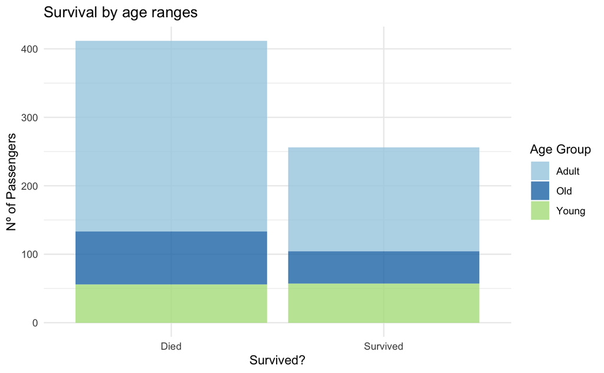

```r
                                                                        #and consequently obtain a better plot

ggplot(df2)+
  geom_bar(aes(Survived, fill=A), alpha=0.8)+
  labs(title="Survival by age ranges",
       x="Survived?",
       fill="Age Group",
       y="Nº of Passengers") +
  scale_fill_brewer(palette = "Paired")+
  theme_minimal()+
  scale_x_discrete(labels=c("Died", "Survived"))
```

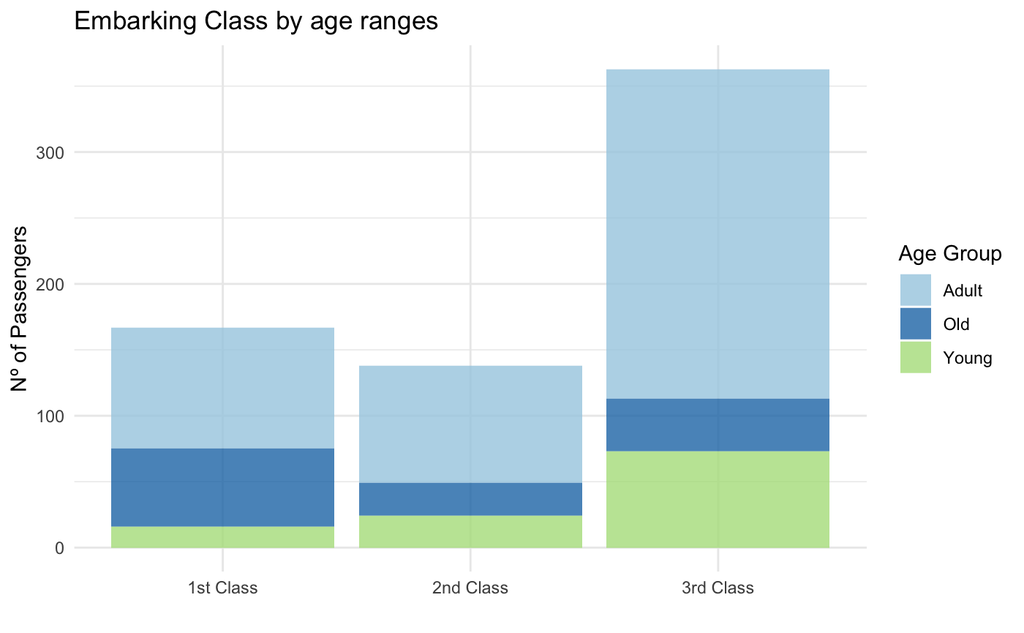

```r
ggplot(df2)+
  geom_bar(aes(Pclass, fill=A), alpha=0.8)+
  labs(title="Embarking Class by age ranges",
       x="",
       fill="Age Group",
       y="Nº of Passengers") +
  scale_fill_brewer(palette = "Paired")+
  theme_minimal()+
  scale_x_discrete(labels=c("1st Class", "2nd Class", "3rd Class"))
```

On the first plot we can observe that young people had a 50% chance of survival, meanwhile old people had less chances of survival and adults had even less chance. Focusing on their boarding class, we see that many old people traveling in first class survived, we believe that its due to the fact that they were in the most expensive class.

### 4.- Is there any relation between the embarking port and survival chances?

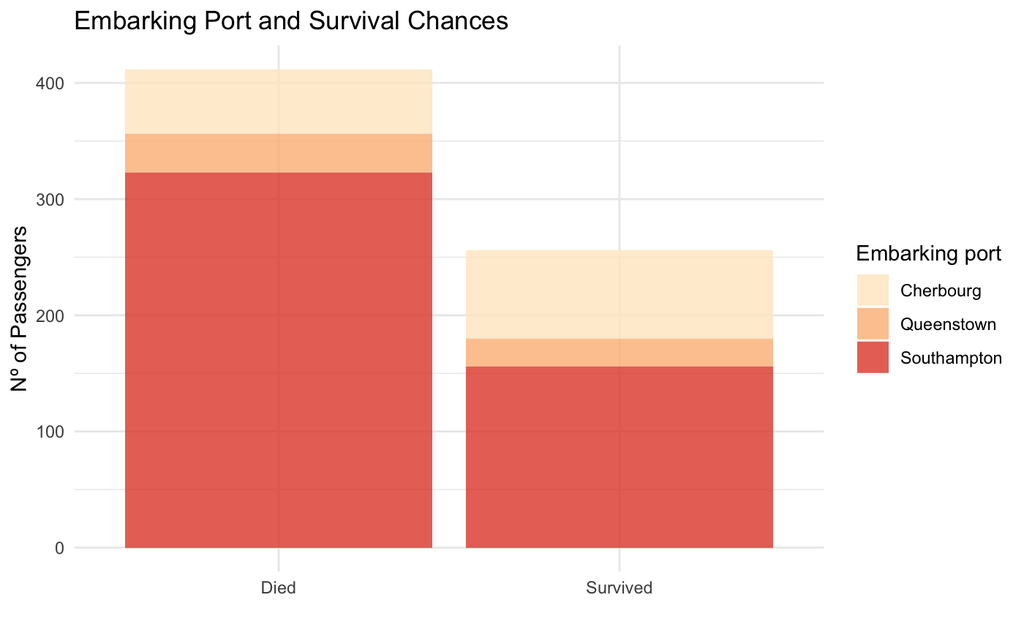

```r
ggplot(titanic.train)+
  geom_bar(aes(x=Survived, fill=Embarked), alpha=0.8)+
  labs(title="Embarking Port and Survival Chances",
       x="",
       fill="Embarking port",
       y="Nº of Passengers") +
  scale_fill_brewer(palette = "OrRd",labels = c("Cherbourg", "Queenstown", "Southampton"))+
  theme_minimal()+
  scale_x_discrete(labels=c("Died", "Survived"))
```

We thought that the probabilty of survival should’ve been similar among the ports but we noticed that when embarking in Cherbourg had slightly greater chances of survival.

### 5.- Having children increases your chances of survival?

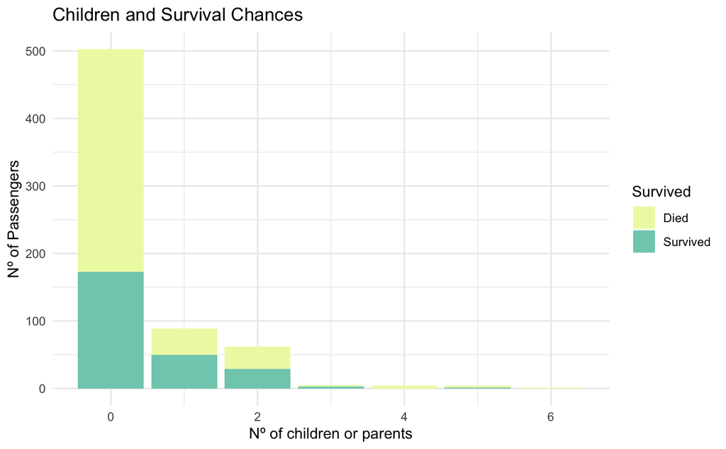

```r
ch <- which(titanic.train$Parch >0)                                         #more filters
ch <- titanic.train[ch,]
ggplot(titanic.train)+
  geom_bar(aes(x = Parch, fill=Survived))+
  labs(title="Children and Survival Chances",
       x="Nº of children or parents",
       y="Nº of Passengers") +
  scale_fill_brewer(palette = "YlGnBu", labels = c("Died", "Survived"))+
  theme_minimal()
```

If we compare the number of people who didn’t have children or parents we surprisingly observe that had less chance of survival. This could be due to the lack of observations from passengers with children, as the vast mayority of them didn’t have children.

### 6.- How where fares computed? What influences the price, the class, the port or the passenger’s gender?

```r
c <- which(titanic.train$Embarked == "C")
q <- which(titanic.train$Embarked == "Q")                         #filtering by where the port was
s <- which(titanic.train$Embarked == "S")

c <- titanic.train[c,]
q <- titanic.train[q,]                                            #obtain filtered data
s <- titanic.train[s,]

df <- data.frame(mean(c$Fare),mean(q$Fare),mean(s$Fare))          #we make a table with the mean price for each filtered port
colnames(df) <- c("Cherbourg", "Queenstown", "Southampton")
df
```

| Cherbourg | Queenstown | Southampton |
| --- | --- | --- |
| 61.74164 | 14.5337 | 28.76331 |

```r
c <- which(titanic.train$Sex == "male")
q <- which(titanic.train$Sex == "female")

c <- titanic.train[c,]
q <- titanic.train[q,]


df <- data.frame(mean(c$Fare),mean(q$Fare))
colnames(df) <- c("Male Fare", "Female Fare")
df
```

| Male Fare | Female Fare |
| --- | --- |
| 26.41336 | 47.44964 |

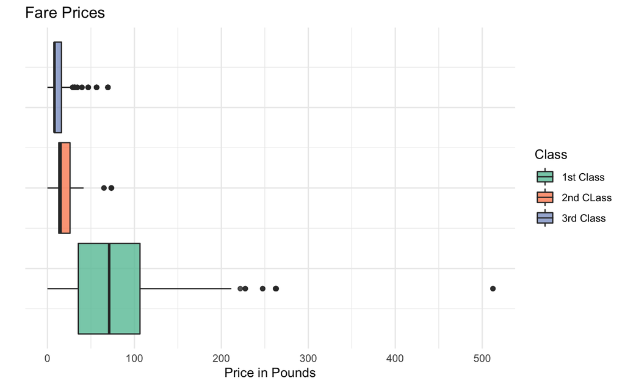

```r
ggplot(titanic.train)+
  geom_boxplot(aes(x = Fare, fill=Pclass), alpha=0.8)+
  labs(title="Fare Prices",
       fill="Class",
       x="Price in Pounds",
       y="") +
  scale_fill_brewer(palette = "Set2", labels = c("1st Class", "2nd CLass", "3rd Class"))+
  theme_minimal()+
  theme(axis.text.y = element_blank())
```